# Лабораторная Работа №4

Эмуляция и измерение задержек в глобальных сетях

Козлов В.П.

Российский университет дружбы народов им. Патриса Лумумбы, Москва, Россия

## Докладчик

- Козлов Всеволод Павлович
- НФИбд-02-22
- Российский университет дружбы народов
- [1132226428@pfur.ru]

# Выполнение лабораторной работы

## Цель работы

Основной целью работы является знакомство с NETEM — инструментом для тестирования производительности приложений в виртуальной сети, а также получение навыков проведения интерактивного и воспроизводимого экспериментов по измерению задержки и её дрожания (jitter) в моделируемой сети в среде Mininet.

## Задание

1. Задайте простейшую топологию, состоящую из двух хостов и коммутатора с назначенной по умолчанию mininet сетью 10.0.0.0/8.
2. Проведите интерактивные эксперименты по добавлению/изменению задержки, джиттера, значения корреляции для джиттера и задержки, распределения времени задержки в эмулируемой глобальной сети.
3. Реализуйте воспроизводимый эксперимент по заданию значения задержки в эмулируемой глобальной сети. Постройте график.
4. Самостоятельно реализуйте воспроизводимые эксперименты по изменению задержки, джиттера, значения корреляции для джиттера и задержки, распределения времени задержки в эмулируемой глобальной сети. Постройте графики.

## Топология, состоящая из двух хостов и коммутатора с назначенной по умолчанию mininet сетью 10.0.0.0/8

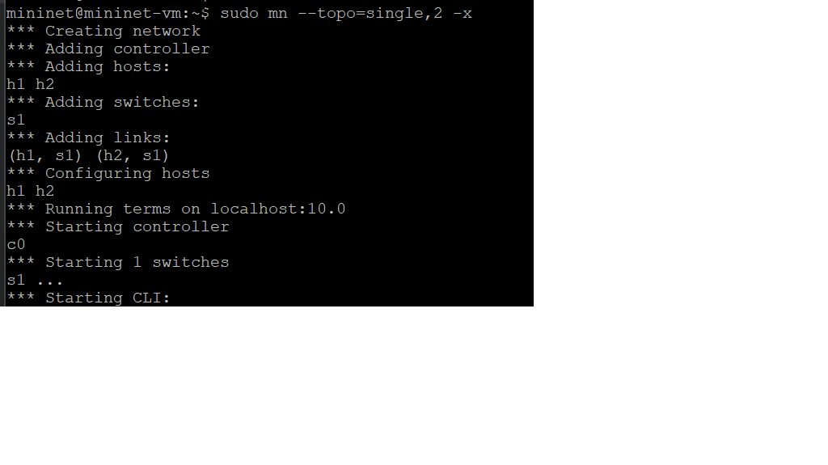

Топология, состоящая из двух хостов и коммутатора

## Просмотрео ifconfig

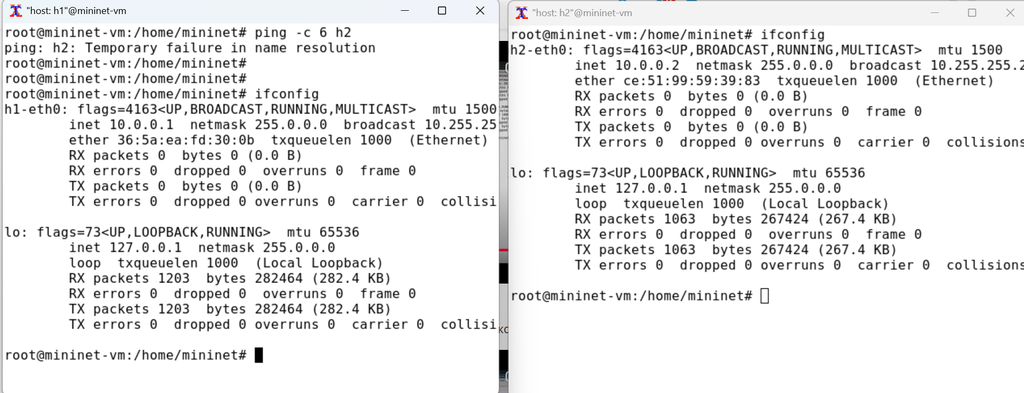

ifconfig

## Пропинговал

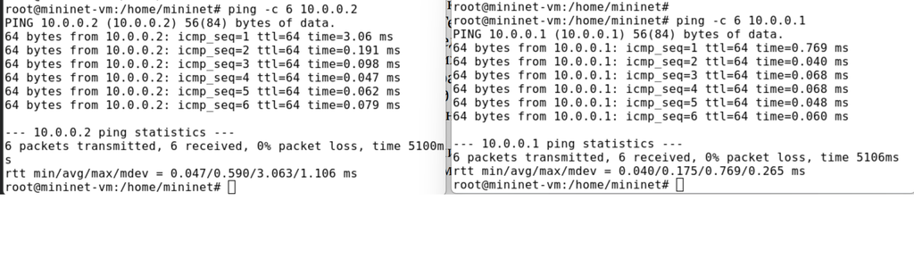

Пингование

## На хосте h1 добавил задержку в 100 мс к выходному интерфейсу

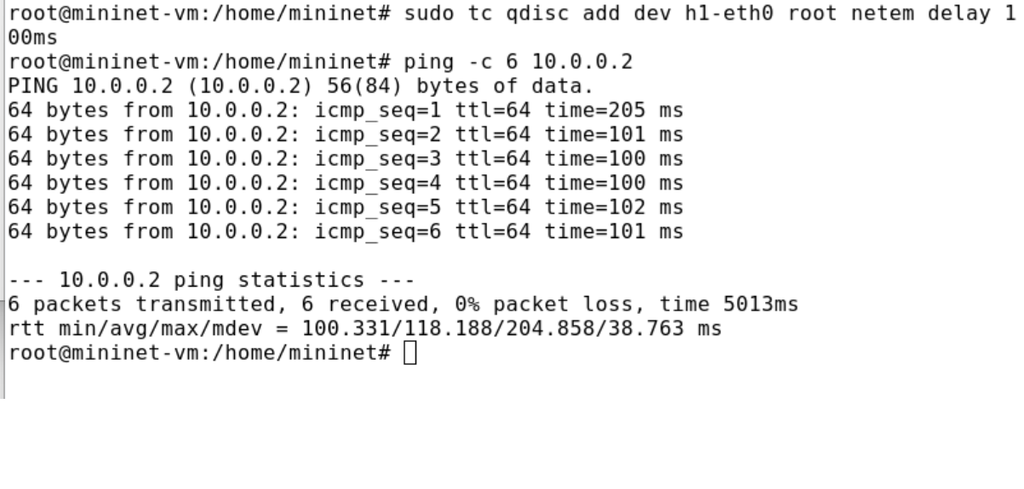

Задержка в 100 мс

## На хосте h2 также добавить задержку в 100 миллисекунд

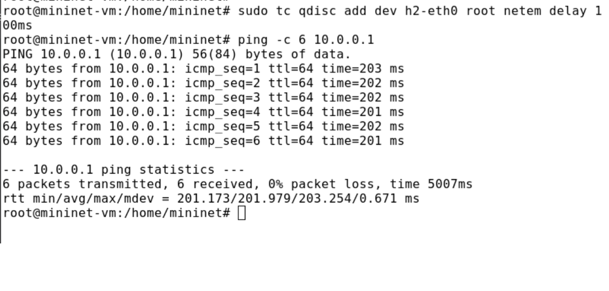

h2 также добавить задержку

## Изменил задержку со 100 мс до 50 мс для отправителя h1 и h2

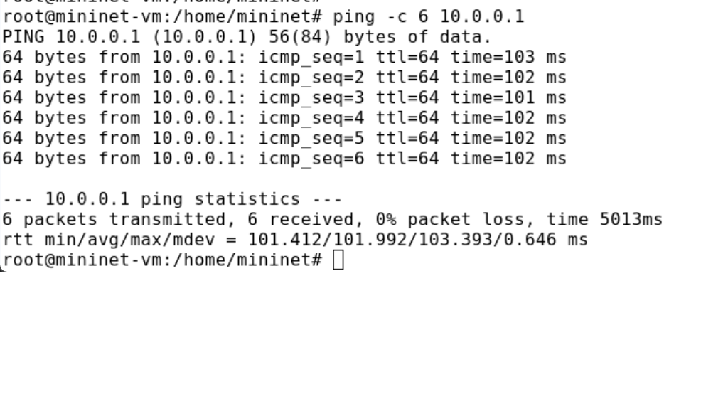

50 мс для отправителя h1 и h2

## Восстановил конфигурацию по умолчанию

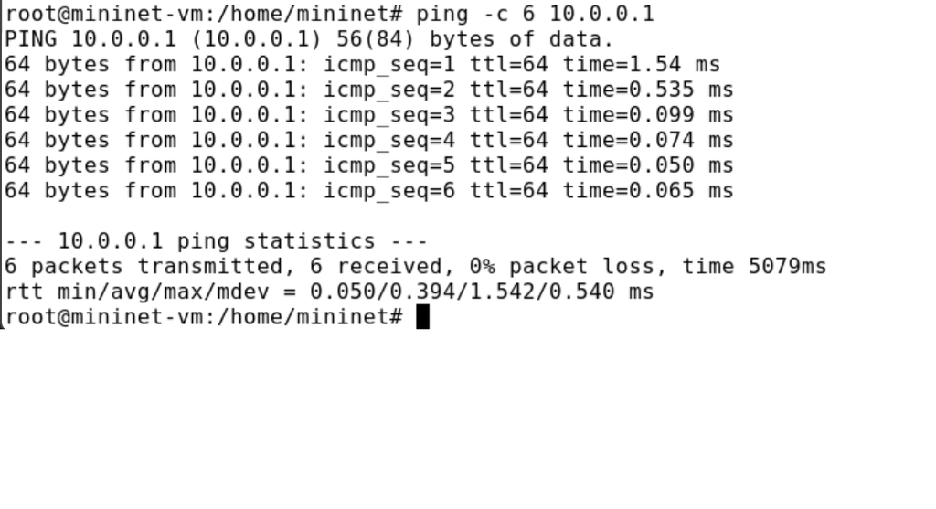

Конфигурация по умолчанию

## h1 задержка в 100 мс со случайным отклонением 10 мс

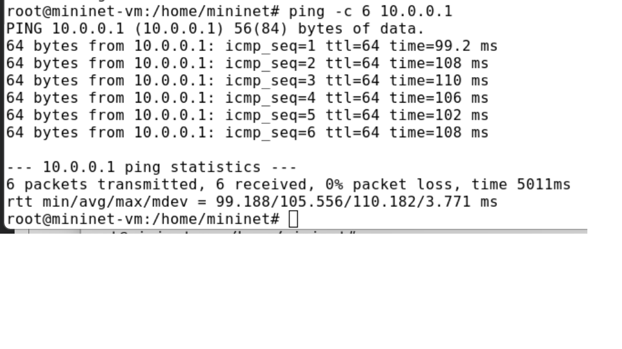

h1 задержка в 100 мс со случайным отклонением 10 мс

## h1 задержку в 100 мс с вариацией +- 10мс и значением корреляции в 25%

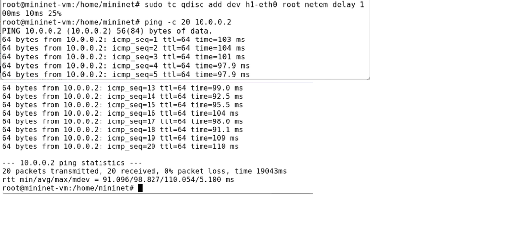

h1 задержку в 100 мс с вариацией +- 10мс и значением корреляции в 25%

## Нормальное распределение задержки на узле h1

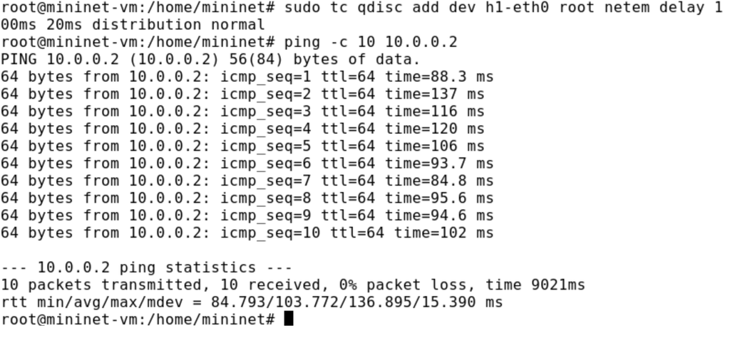

Нормальное распределение задержки на узле h1

## Создал скрипт для эксперимента lab_netem_i.py

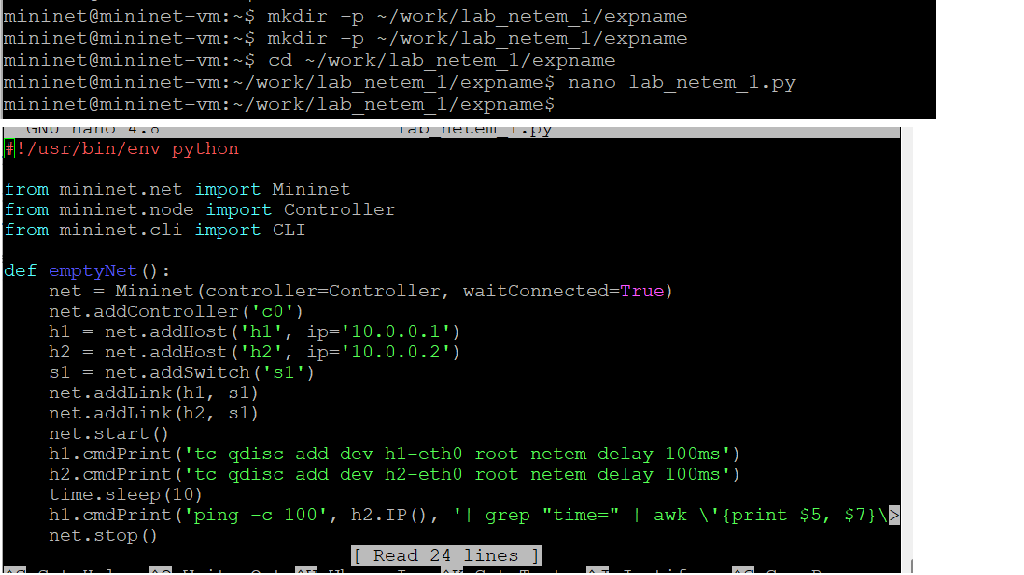

скрипт для эксперимента lab_netem_i.py

## скрипт для визуализации ping_plot

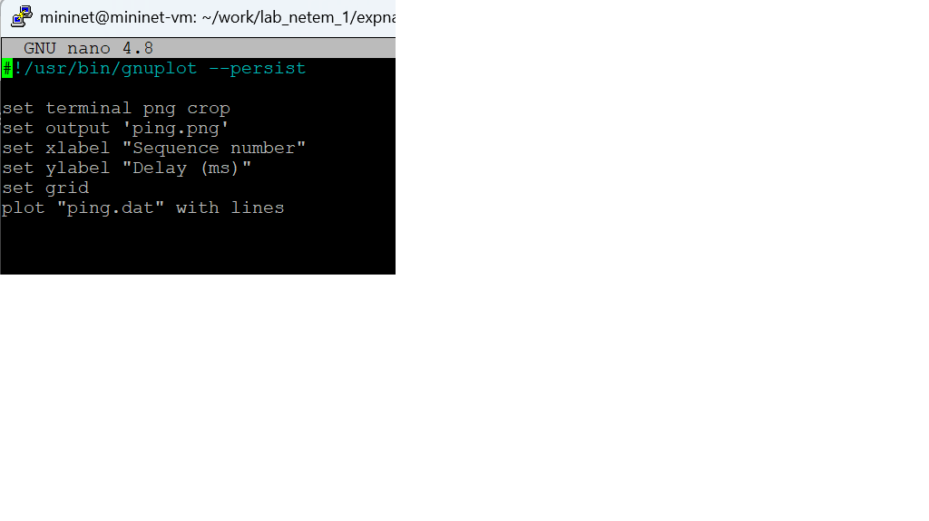

скрипт для визуализации ping_plot

## Запуск make

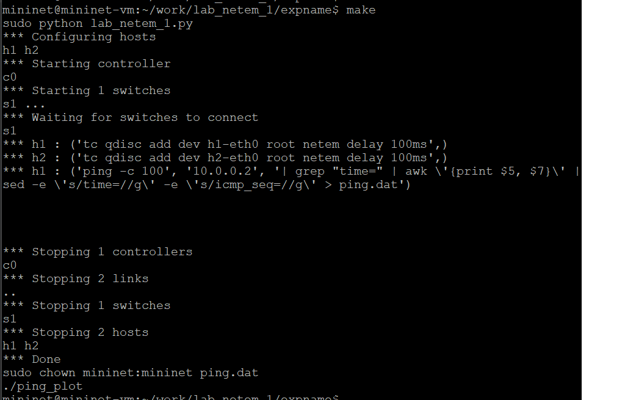

Запуск make

## График

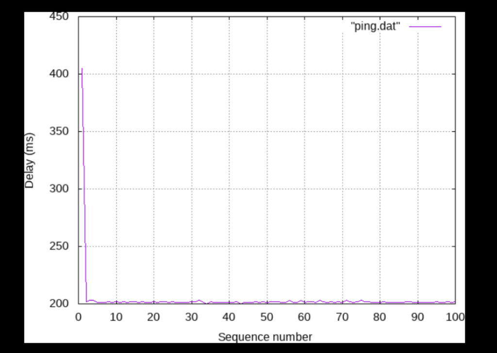

График

## скрипт для вычисления на основе данных файла ping.dat

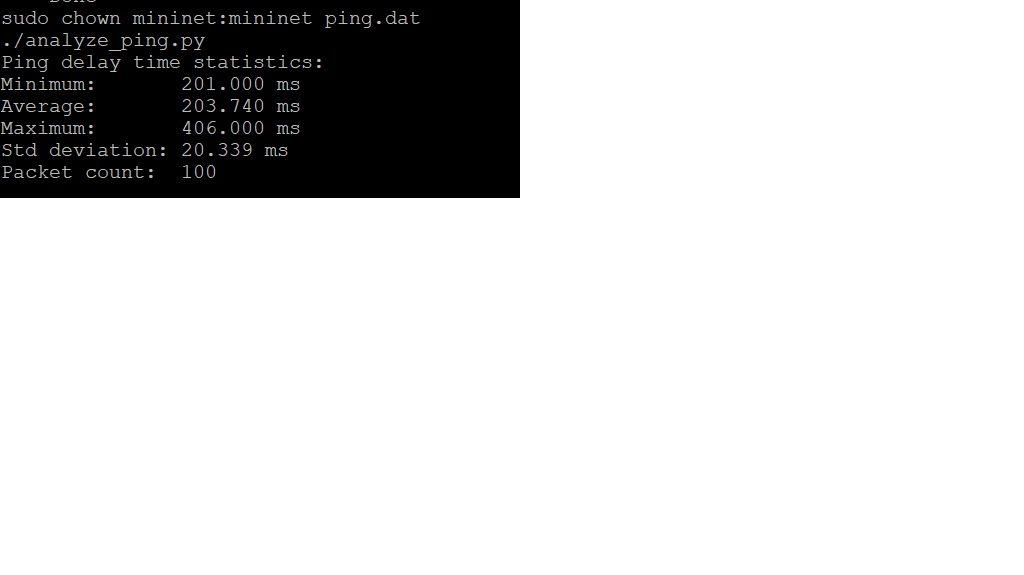

скрипт для вычисления на основе данных файла ping.dat

## Воспроизводимый эксперимент 2

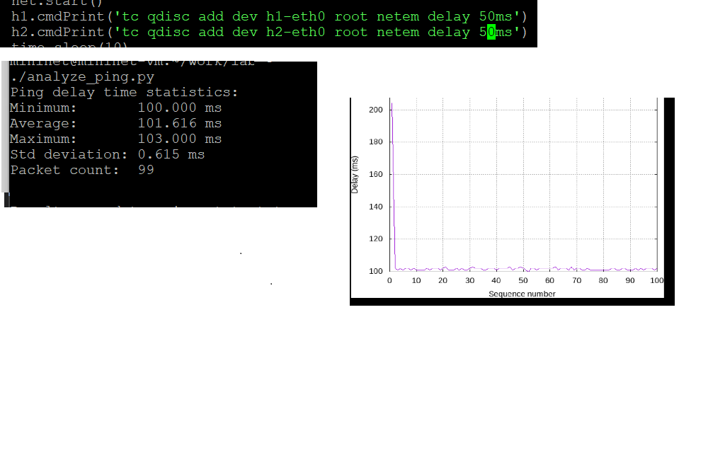

Воспроизводимый эксперимент 2

## Воспроизводимый эксперимент 3

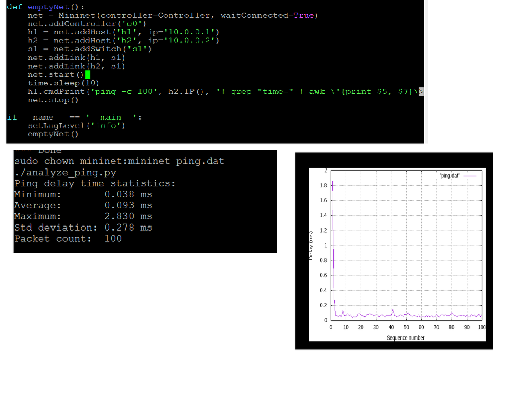

Воспроизводимый эксперимент 3

## Воспроизводимый эксперимент 4

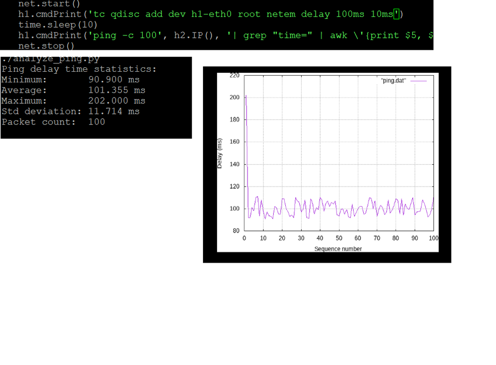

Воспроизводимый эксперимент 4

## Воспроизводимый эксперимент 5

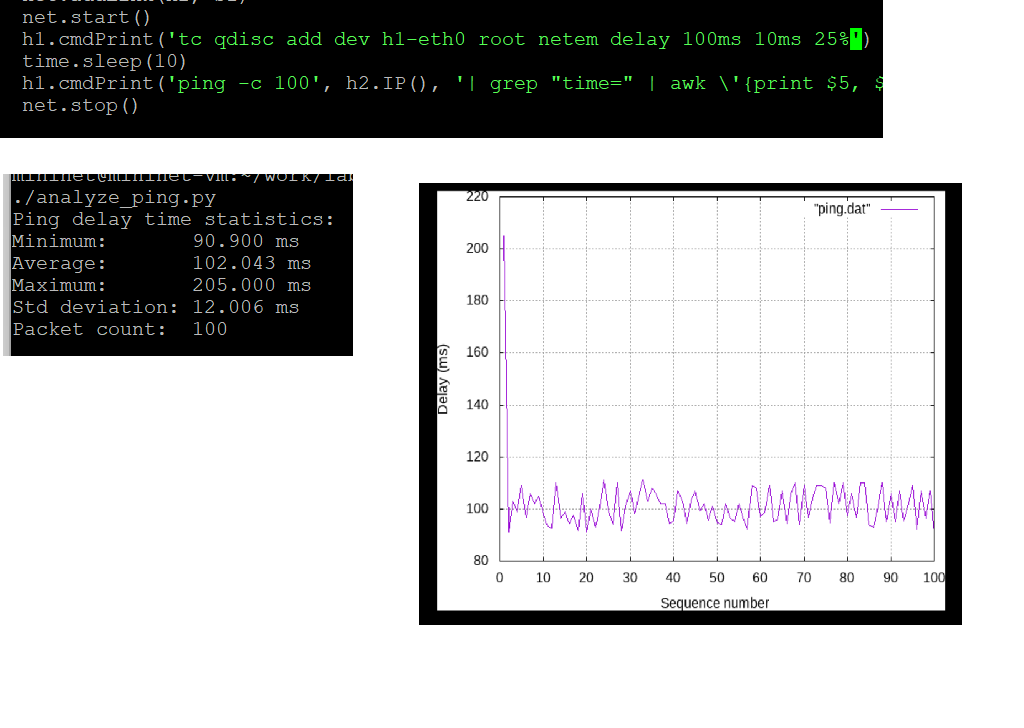

Воспроизводимый эксперимент 5

## Воспроизводимый эксперимент 6

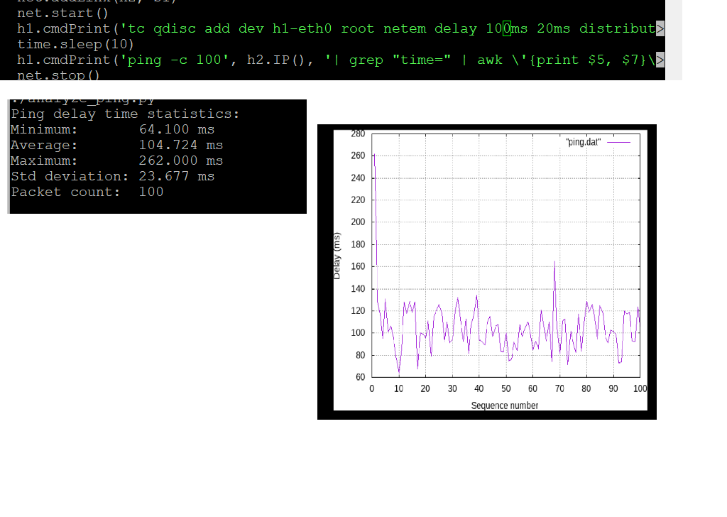

Воспроизводимый эксперимент 6

## Выводы

Озакомился с NETEM — инструментом для тестирования производительности приложений в виртуальной сети, а также получил навыков проведения интерактивного и воспроизводимого экспериментов по измерению задержки и её дрожания (jitter) в моделируемой сети в среде Mininet.